# Optimal Treatment Analysis

## Outcome Variable

**Outcome Variable:** whz

## Predictor Variables

**Intervention Variable:** mbmi

**Adjustment Set:**

- arm
- W_mage
- W_fage
- meducyrs
- feducyrs
- single
- brthmon
- delta_W_mage
- delta_W_fage
- delta_meducyrs
- delta_feducyrs
- delta_single
- delta_brthmon

## Stratifying Variables

The analysis was stratified on these variable(s):

- agecat
- studyid
- country

## Data Summary

| agecat | studyid | country | mbmi | n_cell | n |
| --- | --- | --- | --- | --- | --- |
| Birth | ki0047075b-MAL-ED | BANGLADESH | Normal weight | 205 | 233 |
| Birth | ki0047075b-MAL-ED | BANGLADESH | Underweight | 28 | 233 |
| Birth | ki0047075b-MAL-ED | BRAZIL | Normal weight | 167 | 176 |
| Birth | ki0047075b-MAL-ED | BRAZIL | Underweight | 9 | 176 |
| Birth | ki0047075b-MAL-ED | INDIA | Normal weight | 157 | 195 |
| Birth | ki0047075b-MAL-ED | INDIA | Underweight | 38 | 195 |
| Birth | ki0047075b-MAL-ED | NEPAL | Normal weight | 167 | 167 |
| Birth | ki0047075b-MAL-ED | NEPAL | Underweight | 0 | 167 |
| Birth | ki0047075b-MAL-ED | PERU | Normal weight | 264 | 269 |
| Birth | ki0047075b-MAL-ED | PERU | Underweight | 5 | 269 |
| Birth | ki0047075b-MAL-ED | SOUTH AFRICA | Normal weight | 221 | 226 |
| Birth | ki0047075b-MAL-ED | SOUTH AFRICA | Underweight | 5 | 226 |
| Birth | ki0047075b-MAL-ED | TANZANIA, UNITED REPUBLIC OF | Normal weight | 109 | 116 |
| Birth | ki0047075b-MAL-ED | TANZANIA, UNITED REPUBLIC OF | Underweight | 7 | 116 |
| Birth | ki1000304b-SAS-CompFeed | INDIA | Normal weight | 77 | 110 |
| Birth | ki1000304b-SAS-CompFeed | INDIA | Underweight | 33 | 110 |
| Birth | ki1017093-NIH-Birth | BANGLADESH | Normal weight | 23 | 28 |
| Birth | ki1017093-NIH-Birth | BANGLADESH | Underweight | 5 | 28 |
| Birth | ki1017093c-NIH-Crypto | BANGLADESH | Normal weight | 17 | 23 |
| Birth | ki1017093c-NIH-Crypto | BANGLADESH | Underweight | 6 | 23 |
| Birth | ki1119695-PROBIT | BELARUS | Normal weight | 13143 | 13664 |
| Birth | ki1119695-PROBIT | BELARUS | Underweight | 521 | 13664 |
| Birth | ki1126311-ZVITAMBO | ZIMBABWE | Normal weight | 8573 | 9029 |
| Birth | ki1126311-ZVITAMBO | ZIMBABWE | Underweight | 456 | 9029 |
| 6 months | ki0047075b-MAL-ED | BANGLADESH | Normal weight | 209 | 241 |
| 6 months | ki0047075b-MAL-ED | BANGLADESH | Underweight | 32 | 241 |
| 6 months | ki0047075b-MAL-ED | BRAZIL | Normal weight | 199 | 208 |
| 6 months | ki0047075b-MAL-ED | BRAZIL | Underweight | 9 | 208 |
| 6 months | ki0047075b-MAL-ED | INDIA | Normal weight | 186 | 235 |
| 6 months | ki0047075b-MAL-ED | INDIA | Underweight | 49 | 235 |

[output cut: 52 more lines]

The following strata were considered:

- agecat: 24 months, studyid: ki0047075b-MAL-ED, country: BANGLADESH
- agecat: 24 months, studyid: ki0047075b-MAL-ED, country: BRAZIL
- agecat: 24 months, studyid: ki0047075b-MAL-ED, country: INDIA
- agecat: 24 months, studyid: ki0047075b-MAL-ED, country: NEPAL
- agecat: 24 months, studyid: ki0047075b-MAL-ED, country: PERU
- agecat: 24 months, studyid: ki0047075b-MAL-ED, country: SOUTH AFRICA
- agecat: 24 months, studyid: ki0047075b-MAL-ED, country: TANZANIA, UNITED REPUBLIC OF
- agecat: 24 months, studyid: ki1017093-NIH-Birth, country: BANGLADESH
- agecat: 24 months, studyid: ki1017093b-PROVIDE, country: BANGLADESH
- agecat: 24 months, studyid: ki1017093c-NIH-Crypto, country: BANGLADESH
- agecat: 24 months, studyid: ki1066203-TanzaniaChild2, country: TANZANIA, UNITED REPUBLIC OF
- agecat: 24 months, studyid: ki1119695-PROBIT, country: BELARUS
- agecat: 24 months, studyid: ki1126311-ZVITAMBO, country: ZIMBABWE
- agecat: 24 months, studyid: ki1148112-LCNI-5, country: MALAWI
- agecat: 6 months, studyid: ki0047075b-MAL-ED, country: BANGLADESH
- agecat: 6 months, studyid: ki0047075b-MAL-ED, country: BRAZIL
- agecat: 6 months, studyid: ki0047075b-MAL-ED, country: INDIA
- agecat: 6 months, studyid: ki0047075b-MAL-ED, country: NEPAL
- agecat: 6 months, studyid: ki0047075b-MAL-ED, country: PERU
- agecat: 6 months, studyid: ki0047075b-MAL-ED, country: SOUTH AFRICA
- agecat: 6 months, studyid: ki0047075b-MAL-ED, country: TANZANIA, UNITED REPUBLIC OF
- agecat: 6 months, studyid: ki1000304b-SAS-CompFeed, country: INDIA
- agecat: 6 months, studyid: ki1017093-NIH-Birth, country: BANGLADESH
- agecat: 6 months, studyid: ki1017093b-PROVIDE, country: BANGLADESH
- agecat: 6 months, studyid: ki1017093c-NIH-Crypto, country: BANGLADESH
- agecat: 6 months, studyid: ki1066203-TanzaniaChild2, country: TANZANIA, UNITED REPUBLIC OF
- agecat: 6 months, studyid: ki1119695-PROBIT, country: BELARUS
- agecat: 6 months, studyid: ki1126311-ZVITAMBO, country: ZIMBABWE
- agecat: 6 months, studyid: ki1148112-LCNI-5, country: MALAWI
- agecat: Birth, studyid: ki0047075b-MAL-ED, country: BANGLADESH
- agecat: Birth, studyid: ki0047075b-MAL-ED, country: BRAZIL
- agecat: Birth, studyid: ki0047075b-MAL-ED, country: INDIA
- agecat: Birth, studyid: ki0047075b-MAL-ED, country: NEPAL
- agecat: Birth, studyid: ki0047075b-MAL-ED, country: PERU
- agecat: Birth, studyid: ki0047075b-MAL-ED, country: SOUTH AFRICA
- agecat: Birth, studyid: ki0047075b-MAL-ED, country: TANZANIA, UNITED REPUBLIC OF
- agecat: Birth, studyid: ki1000304b-SAS-CompFeed, country: INDIA
- agecat: Birth, studyid: ki1017093-NIH-Birth, country: BANGLADESH
- agecat: Birth, studyid: ki1017093c-NIH-Crypto, country: BANGLADESH
- agecat: Birth, studyid: ki1119695-PROBIT, country: BELARUS
- agecat: Birth, studyid: ki1126311-ZVITAMBO, country: ZIMBABWE

### Dropped Strata

Some strata were dropped due to rare outcomes:

- agecat: Birth, studyid: ki0047075b-MAL-ED, country: NEPAL
- agecat: 6 months, studyid: ki0047075b-MAL-ED, country: NEPAL
- agecat: 24 months, studyid: ki0047075b-MAL-ED, country: NEPAL
- agecat: 24 months, studyid: ki0047075b-MAL-ED, country: PERU
- agecat: 24 months, studyid: ki1066203-TanzaniaChild2, country: TANZANIA, UNITED REPUBLIC OF

## Methods Detail

We’re interested in the causal parameters $E[Y_a]$ for all values of $a \in \mathcal{A}$. These parameters represent the mean outcome if, possibly contrary to fact, we intervened to set all units to have $A=a$. Under the randomization and positivity assumptions, these are identified by the statistical parameters $\psi_a=E_W[E_{Y|A,W}(Y|A=a,W)]$. In addition, we’re interested in the mean of $Y$, $E[Y]$ under no intervention (the observed mean). We will estimate these parameters by using SuperLearner to fit the relevant likelihood factors – $E_{Y|A,W}(Y|A=a,W)$ and $p(A=a|W)$, and then updating our likelihood fit using a joint TMLE.

For unadjusted analyses ($W=\{\}$), initial likelihoods were estimated using Lrnr_glm to estimate the simple $E(Y|A)$ and Lrnr_mean to estimate $p(A)$. For adjusted analyses, a small library containing Lrnr_glmnet, Lrnr_xgboost, and Lrnr_mean was used.

Having estimated these parameters, we will then use the delta method to estimate relative risks and attributable risks relative to a prespecified baseline level of $A$.

# Results Detail

## Results Plots

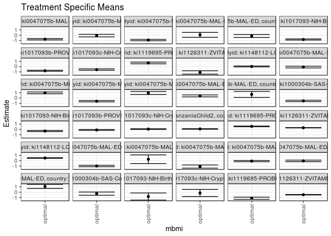

## Results Table

### Parameter: TSM

| agecat | studyid | country | intervention_level | baseline_level | estimate | ci_lower | ci_upper |
| --- | --- | --- | --- | --- | --- | --- | --- |
| Birth | ki0047075b-MAL-ED | BANGLADESH | optimal | observed | -0.9847262 | -1.1208314 | -0.8486211 |
| Birth | ki0047075b-MAL-ED | BRAZIL | optimal | observed | 0.2981131 | -0.5271926 | 1.1234188 |
| Birth | ki0047075b-MAL-ED | INDIA | optimal | observed | -1.0880116 | -1.3896243 | -0.7863990 |
| Birth | ki0047075b-MAL-ED | PERU | optimal | observed | -0.0543167 | -0.1689387 | 0.0603054 |
| Birth | ki0047075b-MAL-ED | SOUTH AFRICA | optimal | observed | -0.0175531 | -0.1682817 | 0.1331755 |
| Birth | ki0047075b-MAL-ED | TANZANIA, UNITED REPUBLIC OF | optimal | observed | 1.0909346 | 0.7148306 | 1.4670386 |
| Birth | ki1000304b-SAS-CompFeed | INDIA | optimal | observed | -0.2703469 | -0.5770181 | 0.0363243 |
| Birth | ki1017093-NIH-Birth | BANGLADESH | optimal | observed | -0.8167189 | -1.4866819 | -0.1467560 |
| Birth | ki1017093c-NIH-Crypto | BANGLADESH | optimal | observed | -0.1460814 | -0.8133415 | 0.5211787 |
| Birth | ki1119695-PROBIT | BELARUS | optimal | observed | -1.1371217 | -1.3469384 | -0.9273049 |
| Birth | ki1126311-ZVITAMBO | ZIMBABWE | optimal | observed | -0.4788108 | -0.5231541 | -0.4344675 |
| 6 months | ki0047075b-MAL-ED | BANGLADESH | optimal | observed | -0.0856476 | -0.2572786 | 0.0859834 |
| 6 months | ki0047075b-MAL-ED | BRAZIL | optimal | observed | 0.9775309 | 0.8089865 | 1.1460753 |
| 6 months | ki0047075b-MAL-ED | INDIA | optimal | observed | -0.6088948 | -0.7398983 | -0.4778912 |
| 6 months | ki0047075b-MAL-ED | PERU | optimal | observed | 0.9486598 | 0.6586543 | 1.2386654 |
| 6 months | ki0047075b-MAL-ED | SOUTH AFRICA | optimal | observed | 0.4053949 | 0.2238283 | 0.5869614 |
| 6 months | ki0047075b-MAL-ED | TANZANIA, UNITED REPUBLIC OF | optimal | observed | 0.6803949 | 0.1091129 | 1.2516769 |
| 6 months | ki1000304b-SAS-CompFeed | INDIA | optimal | observed | -0.5438225 | -0.6770585 | -0.4105864 |
| 6 months | ki1017093-NIH-Birth | BANGLADESH | optimal | observed | -0.3060659 | -0.4034981 | -0.2086336 |
| 6 months | ki1017093b-PROVIDE | BANGLADESH | optimal | observed | -0.1077625 | -0.1997497 | -0.0157753 |
| 6 months | ki1017093c-NIH-Crypto | BANGLADESH | optimal | observed | 0.0608721 | -0.0207424 | 0.1424866 |
| 6 months | ki1066203-TanzaniaChild2 | TANZANIA, UNITED REPUBLIC OF | optimal | observed | 0.0851606 | 0.0306299 | 0.1396913 |
| 6 months | ki1119695-PROBIT | BELARUS | optimal | observed | 0.5711107 | 0.5074463 | 0.6347751 |
| 6 months | ki1126311-ZVITAMBO | ZIMBABWE | optimal | observed | 0.3140104 | 0.2854463 | 0.3425745 |
| 6 months | ki1148112-LCNI-5 | MALAWI | optimal | observed | 0.5270629 | 0.4485897 | 0.6055362 |
| 24 months | ki0047075b-MAL-ED | BANGLADESH | optimal | observed | -0.7673462 | -0.8980592 | -0.6366333 |
| 24 months | ki0047075b-MAL-ED | BRAZIL | optimal | observed | -0.0690694 | -0.3104207 | 0.1722820 |
| 24 months | ki0047075b-MAL-ED | INDIA | optimal | observed | -0.9176375 | -1.0437110 | -0.7915640 |
| 24 months | ki0047075b-MAL-ED | SOUTH AFRICA | optimal | observed | 0.0805420 | -0.3892924 | 0.5503764 |
| 24 months | ki0047075b-MAL-ED | TANZANIA, UNITED REPUBLIC OF | optimal | observed | -0.1455490 | -0.4345124 | 0.1434143 |
| 24 months | ki1017093-NIH-Birth | BANGLADESH | optimal | observed | -0.8151333 | -0.9185894 | -0.7116771 |
| 24 months | ki1017093b-PROVIDE | BANGLADESH | optimal | observed | -0.7843843 | -0.8759701 | -0.6927985 |
| 24 months | ki1017093c-NIH-Crypto | BANGLADESH | optimal | observed | -0.5673126 | -0.7011185 | -0.4335066 |
| 24 months | ki1119695-PROBIT | BELARUS | optimal | observed | 0.6921172 | 0.5370320 | 0.8472024 |
| 24 months | ki1126311-ZVITAMBO | ZIMBABWE | optimal | observed | -1.0985734 | -1.4183818 | -0.7787650 |
| 24 months | ki1148112-LCNI-5 | MALAWI | optimal | observed | 0.0261224 | -0.0636107 | 0.1158554 |

### Parameter: E(Y)

| agecat | studyid | country | intervention_level | baseline_level | estimate | ci_lower | ci_upper |
| --- | --- | --- | --- | --- | --- | --- | --- |
| Birth | ki0047075b-MAL-ED | BANGLADESH | observed | observed | -0.9724464 | -1.1091046 | -0.8357881 |
| Birth | ki0047075b-MAL-ED | BRAZIL | observed | observed | 0.3832386 | 0.2044597 | 0.5620175 |
| Birth | ki0047075b-MAL-ED | INDIA | observed | observed | -1.0698974 | -1.2115847 | -0.9282102 |
| Birth | ki0047075b-MAL-ED | PERU | observed | observed | -0.0660967 | -0.1789362 | 0.0467429 |
| Birth | ki0047075b-MAL-ED | SOUTH AFRICA | observed | observed | -0.0346018 | -0.1831486 | 0.1139451 |
| Birth | ki0047075b-MAL-ED | TANZANIA, UNITED REPUBLIC OF | observed | observed | 0.7950000 | 0.5947353 | 0.9952647 |
| Birth | ki1000304b-SAS-CompFeed | INDIA | observed | observed | -0.1601818 | -0.3763991 | 0.0560355 |
| Birth | ki1017093-NIH-Birth | BANGLADESH | observed | observed | -1.4239286 | -1.7688028 | -1.0790544 |
| Birth | ki1017093c-NIH-Crypto | BANGLADESH | observed | observed | -0.7508696 | -1.2358912 | -0.2658480 |
| Birth | ki1119695-PROBIT | BELARUS | observed | observed | -1.1441269 | -1.3547476 | -0.9335062 |
| Birth | ki1126311-ZVITAMBO | ZIMBABWE | observed | observed | -0.4900343 | -0.5209436 | -0.4591251 |
| 6 months | ki0047075b-MAL-ED | BANGLADESH | observed | observed | -0.1397960 | -0.2688682 | -0.0107238 |
| 6 months | ki0047075b-MAL-ED | BRAZIL | observed | observed | 0.9644952 | 0.7999744 | 1.1290160 |
| 6 months | ki0047075b-MAL-ED | INDIA | observed | observed | -0.6987943 | -0.8241325 | -0.5734561 |
| 6 months | ki0047075b-MAL-ED | PERU | observed | observed | 1.0563787 | 0.9342938 | 1.1784635 |
| 6 months | ki0047075b-MAL-ED | SOUTH AFRICA | observed | observed | 0.5290428 | 0.3750394 | 0.6830463 |
| 6 months | ki0047075b-MAL-ED | TANZANIA, UNITED REPUBLIC OF | observed | observed | 0.5170513 | 0.3872178 | 0.6468847 |
| 6 months | ki1000304b-SAS-CompFeed | INDIA | observed | observed | -0.6441020 | -0.7710827 | -0.5171213 |
| 6 months | ki1017093-NIH-Birth | BANGLADESH | observed | observed | -0.4389101 | -0.5279432 | -0.3498771 |
| 6 months | ki1017093b-PROVIDE | BANGLADESH | observed | observed | -0.2079891 | -0.2925599 | -0.1234183 |
| 6 months | ki1017093c-NIH-Crypto | BANGLADESH | observed | observed | 0.0297622 | -0.0491685 | 0.1086930 |
| 6 months | ki1066203-TanzaniaChild2 | TANZANIA, UNITED REPUBLIC OF | observed | observed | 0.0775172 | 0.0241750 | 0.1308595 |
| 6 months | ki1119695-PROBIT | BELARUS | observed | observed | 0.5829956 | 0.5247249 | 0.6412663 |
| 6 months | ki1126311-ZVITAMBO | ZIMBABWE | observed | observed | 0.2928094 | 0.2648167 | 0.3208020 |
| 6 months | ki1148112-LCNI-5 | MALAWI | observed | observed | 0.4515431 | 0.3802415 | 0.5228446 |
| 24 months | ki0047075b-MAL-ED | BANGLADESH | observed | observed | -0.8208255 | -0.9429246 | -0.6987264 |
| 24 months | ki0047075b-MAL-ED | BRAZIL | observed | observed | 0.4282738 | 0.2252365 | 0.6313111 |
| 24 months | ki0047075b-MAL-ED | INDIA | observed | observed | -0.9525664 | -1.0684455 | -0.8366872 |
| 24 months | ki0047075b-MAL-ED | SOUTH AFRICA | observed | observed | 0.4096154 | 0.2902946 | 0.5289362 |
| 24 months | ki0047075b-MAL-ED | TANZANIA, UNITED REPUBLIC OF | observed | observed | 0.0500935 | -0.0748234 | 0.1750103 |
| 24 months | ki1017093-NIH-Birth | BANGLADESH | observed | observed | -0.9115790 | -1.0095022 | -0.8136559 |
| 24 months | ki1017093b-PROVIDE | BANGLADESH | observed | observed | -0.8864991 | -0.9695215 | -0.8034768 |
| 24 months | ki1017093c-NIH-Crypto | BANGLADESH | observed | observed | -0.6103502 | -0.7050157 | -0.5156847 |
| 24 months | ki1119695-PROBIT | BELARUS | observed | observed | 0.6869754 | 0.5725638 | 0.8013869 |
| 24 months | ki1126311-ZVITAMBO | ZIMBABWE | observed | observed | -1.1810028 | -1.2914599 | -1.0705456 |
| 24 months | ki1148112-LCNI-5 | MALAWI | observed | observed | -0.0469519 | -0.1290932 | 0.0351895 |

### Parameter: PAR

| agecat | studyid | country | intervention_level | baseline_level | estimate | ci_lower | ci_upper |
| --- | --- | --- | --- | --- | --- | --- | --- |
| Birth | ki0047075b-MAL-ED | BANGLADESH | optimal | observed | 0.0122799 | -0.0652887 | 0.0898485 |
| Birth | ki0047075b-MAL-ED | BRAZIL | optimal | observed | 0.0851255 | -0.7180287 | 0.8882798 |
| Birth | ki0047075b-MAL-ED | INDIA | optimal | observed | 0.0181142 | -0.2363986 | 0.2726270 |
| Birth | ki0047075b-MAL-ED | PERU | optimal | observed | -0.0117800 | -0.0278050 | 0.0042451 |
| Birth | ki0047075b-MAL-ED | SOUTH AFRICA | optimal | observed | -0.0170487 | -0.0393879 | 0.0052905 |
| Birth | ki0047075b-MAL-ED | TANZANIA, UNITED REPUBLIC OF | optimal | observed | -0.2959346 | -0.7047843 | 0.1129151 |
| Birth | ki1000304b-SAS-CompFeed | INDIA | optimal | observed | 0.1101651 | -0.0754877 | 0.2958178 |
| Birth | ki1017093-NIH-Birth | BANGLADESH | optimal | observed | -0.6072096 | -1.2727051 | 0.0582858 |
| Birth | ki1017093c-NIH-Crypto | BANGLADESH | optimal | observed | -0.6047881 | -1.2963136 | 0.0867373 |
| Birth | ki1119695-PROBIT | BELARUS | optimal | observed | -0.0070052 | -0.0128348 | -0.0011757 |
| Birth | ki1126311-ZVITAMBO | ZIMBABWE | optimal | observed | -0.0112235 | -0.0426942 | 0.0202471 |
| 6 months | ki0047075b-MAL-ED | BANGLADESH | optimal | observed | -0.0541484 | -0.1836591 | 0.0753623 |
| 6 months | ki0047075b-MAL-ED | BRAZIL | optimal | observed | -0.0130357 | -0.0473143 | 0.0212430 |
| 6 months | ki0047075b-MAL-ED | INDIA | optimal | observed | -0.0898995 | -0.1678799 | -0.0119192 |
| 6 months | ki0047075b-MAL-ED | PERU | optimal | observed | 0.1077188 | -0.1588122 | 0.3742499 |
| 6 months | ki0047075b-MAL-ED | SOUTH AFRICA | optimal | observed | 0.1236480 | 0.0335138 | 0.2137822 |
| 6 months | ki0047075b-MAL-ED | TANZANIA, UNITED REPUBLIC OF | optimal | observed | -0.1633436 | -0.7220669 | 0.3953797 |
| 6 months | ki1000304b-SAS-CompFeed | INDIA | optimal | observed | -0.1002796 | -0.1316405 | -0.0689187 |
| 6 months | ki1017093-NIH-Birth | BANGLADESH | optimal | observed | -0.1328443 | -0.1883023 | -0.0773863 |
| 6 months | ki1017093b-PROVIDE | BANGLADESH | optimal | observed | -0.1002266 | -0.1417374 | -0.0587158 |
| 6 months | ki1017093c-NIH-Crypto | BANGLADESH | optimal | observed | -0.0311099 | -0.0597862 | -0.0024336 |
| 6 months | ki1066203-TanzaniaChild2 | TANZANIA, UNITED REPUBLIC OF | optimal | observed | -0.0076434 | -0.0139567 | -0.0013301 |
| 6 months | ki1119695-PROBIT | BELARUS | optimal | observed | 0.0118849 | -0.0156635 | 0.0394333 |
| 6 months | ki1126311-ZVITAMBO | ZIMBABWE | optimal | observed | -0.0212010 | -0.0284462 | -0.0139558 |
| 6 months | ki1148112-LCNI-5 | MALAWI | optimal | observed | -0.0755199 | -0.1090278 | -0.0420120 |
| 24 months | ki0047075b-MAL-ED | BANGLADESH | optimal | observed | -0.0534792 | -0.1061105 | -0.0008480 |
| 24 months | ki0047075b-MAL-ED | BRAZIL | optimal | observed | 0.4973432 | 0.2971511 | 0.6975352 |
| 24 months | ki0047075b-MAL-ED | INDIA | optimal | observed | -0.0349289 | -0.1008362 | 0.0309785 |
| 24 months | ki0047075b-MAL-ED | SOUTH AFRICA | optimal | observed | 0.3290734 | -0.1377863 | 0.7959332 |
| 24 months | ki0047075b-MAL-ED | TANZANIA, UNITED REPUBLIC OF | optimal | observed | 0.1956425 | -0.0658556 | 0.4571406 |
| 24 months | ki1017093-NIH-Birth | BANGLADESH | optimal | observed | -0.0964458 | -0.1508131 | -0.0420784 |
| 24 months | ki1017093b-PROVIDE | BANGLADESH | optimal | observed | -0.1021148 | -0.1459106 | -0.0583191 |
| 24 months | ki1017093c-NIH-Crypto | BANGLADESH | optimal | observed | -0.0430376 | -0.1288876 | 0.0428124 |
| 24 months | ki1119695-PROBIT | BELARUS | optimal | observed | -0.0051418 | -0.0809788 | 0.0706952 |
| 24 months | ki1126311-ZVITAMBO | ZIMBABWE | optimal | observed | -0.0824294 | -0.3718370 | 0.2069782 |
| 24 months | ki1148112-LCNI-5 | MALAWI | optimal | observed | -0.0730742 | -0.1120745 | -0.0340740 |